# ch01_01_ML_start_v11

## ch01 머신러닝 시작하기

- Machine Learning with sklearn @ DJ,Lim
- date : 2021/02

### 01 기본 개념 이해하기

- **샘플(sample) or 데이터 포인터(data point)** : 하나의 개체 혹은 행을 말한다.
- 특성 or 속성(feature) : 샘플의 속성, 즉 열을 가르킨다.

### 02 기본 라이브러리 이해하기

### scikit-learn(사이킷 런)

- 오픈 소스입니다.
- 매우 인기 높고 독보적인 파이썬 머신러닝 라이브러리입니다.
- url : http://scikit-learn.org/stable/documentation
- 사용자 가이드 : https://scikit-learn.org/stable/user_guide.html

### Numpy

- 파이썬으로 과학 계산을 하기 위한 꼭 필요한 패키지
- 다차원 배열을 위한 기능
- 선형 대수 연산 기능
- 푸리에 변환 같은 고수준 수학 함수와 유사 난수 생성기 기능
- url : https://www.numpy.org/

### SciPy

- SciPy(https://www.scipy.org/scipylib) 과학 계산용 함수를 모아놓은 파이썬 패키지.
- 고성능 선형대수 기능, 함수 최적화, 신호 처리, 특수한 수학 함수와 통계 분포 등
- 희소 행렬 기능

### Matplotlib

- 파이썬 대표적인 과학 계산용 그래프 라이브러리

### Pandas

- 데이터 처리와 분석을 위한 파이썬 라이브러리
- url : https://pandas.pydata.org/
- R의 data.frame을 본떠 설계한 **Dataframe**이라는 데이터 구조를 기반으로 만들어짐.
- SQL 처럼 테이블 쿼리나 조인을 수행 가능함.
- xlsx, csv등의 다양한 파일과 데이터베이스에서 데이터를 읽어들 일 수 있음.
- 참고 도서 : 파이썬 라이브러리를 활용한 데이터 분석
- https://pandas.pydata.org/pandas-docs/stable/getting_started/10min.html

### mglearn

- 깃허브에 있는 코드와 함께 작성.

```python
from IPython.display import display, Image
```

### 03 라이브러리 소프트웨어 버전 확인

```
라이브러리이름.__version__
라이브러리이름.version
```

```python
import sys
print("파이썬 버전 :", sys.version)
```

```
파이썬 버전 : 3.7.6 (default, Jan  8 2020, 20:23:39) [MSC v.1916 64 bit (AMD64)]
```

```python
import pandas as pd
print("판다스 버전 :", pd.__version__)
```

```
판다스 버전 : 1.0.1
```

```python
import matplotlib
import numpy as np
import scipy as sp
```

### 직접 해보기1

- matplotlib, numpy, seaborn, scipy의 각각의 버전을 확인해 보자.
- 추가 라이브러리를 설치할 때 명령
  - pip install [라이브러리명]

### 04 머신러닝 모델을 위한 iris 데이터를 준비

### 데이터 : 붓꽃

- 종류 : setosa, versicolor, virginica
- 데이터 내용 : 붓꽃의 꽃잎과 꽃받침
- 우리가 해결하려고 하는 문제 : 데이터를 주고 붓꽃의 종류 예측하기

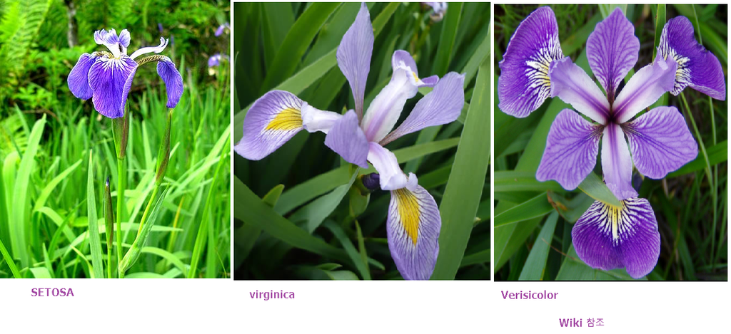

```python
display(Image(filename='img/iris_setosa01.png'))
```

### 용어 이해하기

- **클래스(class)** : 출력될 수 있는 값들. 붓꽃의 종류들, 붓꽃의 종류는 세 클래스 중 하나에 속한다.
- **레이블(label)** : 데이터 포인트 하나(붓꽃 하나)에 대한 기대 출력. **특정 데이터 포인트에 대한 출력**

### 데이터 준비

- load_iris가 반환한 iris객체는 파이썬의 딕셔너리(Dictionary)와 유사한 Bunch 클래스의 객체

```python
from sklearn.datasets import load_iris
iris = load_iris()
iris
```

```
{'data': array([[5.1, 3.5, 1.4, 0.2],
        [4.9, 3. , 1.4, 0.2],
        [4.7, 3.2, 1.3, 0.2],
        [4.6, 3.1, 1.5, 0.2],
        [5. , 3.6, 1.4, 0.2],
        [5.4, 3.9, 1.7, 0.4],
        [4.6, 3.4, 1.4, 0.3],
        [5. , 3.4, 1.5, 0.2],
        [4.4, 2.9, 1.4, 0.2],
        [4.9, 3.1, 1.5, 0.1],
        [5.4, 3.7, 1.5, 0.2],
        [4.8, 3.4, 1.6, 0.2],
        [4.8, 3. , 1.4, 0.1],
        [4.3, 3. , 1.1, 0.1],
        [5.8, 4. , 1.2, 0.2],
        [5.7, 4.4, 1.5, 0.4],
        [5.4, 3.9, 1.3, 0.4],
        [5.1, 3.5, 1.4, 0.3],
        [5.7, 3.8, 1.7, 0.3],
        [5.1, 3.8, 1.5, 0.3],
        [5.4, 3.4, 1.7, 0.2],
        [5.1, 3.7, 1.5, 0.4],
        [4.6, 3.6, 1. , 0.2],
        [5.1, 3.3, 1.7, 0.5],
        [4.8, 3.4, 1.9, 0.2],
        [5. , 3. , 1.6, 0.2],
        [5. , 3.4, 1.6, 0.4],
        [5.2, 3.5, 1.5, 0.2],
        [5.2, 3.4, 1.4, 0.2],
        [4.7, 3.2, 1.6, 0.2],
        [4.8, 3.1, 1.6, 0.2],
        [5.4, 3.4, 1.5, 0.4],
        [5.2, 4.1, 1.5, 0.1],
        [5.5, 4.2, 1.4, 0.2],
        [4.9, 3.1, 1.5, 0.2],
        [5. , 3.2, 1.2, 0.2],
        [5.5, 3.5, 1.3, 0.2],
        [4.9, 3.6, 1.4, 0.1],
        [4.4, 3. , 1.3, 0.2],
        [5.1, 3.4, 1.5, 0.2],
```

[output cut: 109 more lines]

```
        [5.9, 3. , 5.1, 1.8]]),
 'target': array([0, 0, 0, 0, 0, 0, 0, 0, 0, 0, 0, 0, 0, 0, 0, 0, 0, 0, 0, 0, 0, 0,
        0, 0, 0, 0, 0, 0, 0, 0, 0, 0, 0, 0, 0, 0, 0, 0, 0, 0, 0, 0, 0, 0,
        0, 0, 0, 0, 0, 0, 1, 1, 1, 1, 1, 1, 1, 1, 1, 1, 1, 1, 1, 1, 1, 1,
        1, 1, 1, 1, 1, 1, 1, 1, 1, 1, 1, 1, 1, 1, 1, 1, 1, 1, 1, 1, 1, 1,
        1, 1, 1, 1, 1, 1, 1, 1, 1, 1, 1, 1, 2, 2, 2, 2, 2, 2, 2, 2, 2, 2,
        2, 2, 2, 2, 2, 2, 2, 2, 2, 2, 2, 2, 2, 2, 2, 2, 2, 2, 2, 2, 2, 2,
        2, 2, 2, 2, 2, 2, 2, 2, 2, 2, 2, 2, 2, 2, 2, 2, 2, 2]),
 'target_names': array(['setosa', 'versicolor', 'virginica'], dtype='<U10'),
 'DESCR': '.. _iris_dataset:\n\nIris plants dataset\n--------------------\n\n**Data Set Characteristics:**\n\n    :Number of Instances: 150 (50 in each of three classes)\n    :Number of Attributes: 4 numeric, predictive attributes and the class\n    :Attribute Information:\n        - sepal length in…
 'feature_names': ['sepal length (cm)',
  'sepal width (cm)',
  'petal length (cm)',
  'petal width (cm)'],
 'filename': 'C:\\Users\\front\\anaconda3\\lib\\site-packages\\sklearn\\datasets\\data\\iris.csv'}
```

```python
# iris 데이터 셋의 key값들
print(iris.keys())
print(iris['target_names']) # 붓꽃의 label의 종류명
print(iris['target'])   # 붓꽃의 종류의 label의 값
print(iris['data'])  # 붓꽃의 꽃잎과 꽃받침의 값
```

```
dict_keys(['data', 'target', 'target_names', 'DESCR', 'feature_names', 'filename'])
['setosa' 'versicolor' 'virginica']
[0 0 0 0 0 0 0 0 0 0 0 0 0 0 0 0 0 0 0 0 0 0 0 0 0 0 0 0 0 0 0 0 0 0 0 0 0
 0 0 0 0 0 0 0 0 0 0 0 0 0 1 1 1 1 1 1 1 1 1 1 1 1 1 1 1 1 1 1 1 1 1 1 1 1
 1 1 1 1 1 1 1 1 1 1 1 1 1 1 1 1 1 1 1 1 1 1 1 1 1 1 2 2 2 2 2 2 2 2 2 2 2
 2 2 2 2 2 2 2 2 2 2 2 2 2 2 2 2 2 2 2 2 2 2 2 2 2 2 2 2 2 2 2 2 2 2 2 2 2
 2 2]
[[5.1 3.5 1.4 0.2]
 [4.9 3.  1.4 0.2]
 [4.7 3.2 1.3 0.2]
 [4.6 3.1 1.5 0.2]
 [5.  3.6 1.4 0.2]
 [5.4 3.9 1.7 0.4]
 [4.6 3.4 1.4 0.3]
 [5.  3.4 1.5 0.2]
 [4.4 2.9 1.4 0.2]
 [4.9 3.1 1.5 0.1]
 [5.4 3.7 1.5 0.2]
 [4.8 3.4 1.6 0.2]
 [4.8 3.  1.4 0.1]
 [4.3 3.  1.1 0.1]
 [5.8 4.  1.2 0.2]
 [5.7 4.4 1.5 0.4]
 [5.4 3.9 1.3 0.4]
 [5.1 3.5 1.4 0.3]
 [5.7 3.8 1.7 0.3]
 [5.1 3.8 1.5 0.3]
 [5.4 3.4 1.7 0.2]
 [5.1 3.7 1.5 0.4]
 [4.6 3.6 1.  0.2]
 [5.1 3.3 1.7 0.5]
 [4.8 3.4 1.9 0.2]
 [5.  3.  1.6 0.2]
 [5.  3.4 1.6 0.4]
 [5.2 3.5 1.5 0.2]
 [5.2 3.4 1.4 0.2]
 [4.7 3.2 1.6 0.2]
 [4.8 3.1 1.6 0.2]
 [5.4 3.4 1.5 0.4]
 [5.2 4.1 1.5 0.1]
```

[output cut: 102 more lines]

```
 [7.7 3.  6.1 2.3]
 [6.3 3.4 5.6 2.4]
 [6.4 3.1 5.5 1.8]
 [6.  3.  4.8 1.8]
 [6.9 3.1 5.4 2.1]
 [6.7 3.1 5.6 2.4]
 [6.9 3.1 5.1 2.3]
 [5.8 2.7 5.1 1.9]
 [6.8 3.2 5.9 2.3]
 [6.7 3.3 5.7 2.5]
 [6.7 3.  5.2 2.3]
 [6.3 2.5 5.  1.9]
 [6.5 3.  5.2 2. ]
 [6.2 3.4 5.4 2.3]
 [5.9 3.  5.1 1.8]]
```

```python
# iris 데이터 셋의 설명 확인
iris['DESCR']
```

```
'.. _iris_dataset:\n\nIris plants dataset\n--------------------\n\n**Data Set Characteristics:**\n\n    :Number of Instances: 150 (50 in each of three classes)\n    :Number of Attributes: 4 numeric, predictive attributes and the class\n    :Attribute Information:\n        - sepal length in cm\n     …
```

```python
# iris 데이터 셋의 행열 확인
print( iris['data'].shape )
print( iris['feature_names'])
print( iris['data'][:5])      # 5개의 데이터 확인
print( iris['target_names'][:5])
print( iris['target'][:5])
```

```
(150, 4)
['sepal length (cm)', 'sepal width (cm)', 'petal length (cm)', 'petal width (cm)']
[[5.1 3.5 1.4 0.2]
 [4.9 3.  1.4 0.2]
 [4.7 3.2 1.3 0.2]
 [4.6 3.1 1.5 0.2]
 [5.  3.6 1.4 0.2]]
['setosa' 'versicolor' 'virginica']
[0 0 0 0 0]
```

### 데이터의 크기 확인

- 데이터의 사이즈 확인 : 데이터.shape
- 데이터의 자료형 확인 : type(데이터자료형)

```python
print(iris['target'].shape)  # 타켓
print(iris['data'].shape)
print(type(iris['target']) , type(iris['data']) )
```

```
(150,)
(150, 4)
<class 'numpy.ndarray'> <class 'numpy.ndarray'>
```

### 05 데이터를 훈련 데이터와 테스트 데이터로 나누기

- 학습용 데이터 : 실제 공부를 위한 데이터 셋(실제 문제지의 문제)
- 테스트 데이터 : 공부 후, 실제 잘 동작하는지 확인하기 위한 데이터 (모의고사시험)
- 내용 : 모델을 새 데이터에 적용하기 전에 우리가 만든 모델이 잘 동작하는지 확인하기 위해 테스트 데이터를 활용하여 평가한다.

#### 훈련 데이터 셋(training set) : 머신러닝 모델을 만들 때 쓰는 데이터 셋

#### 테스트 데이터 셋(test set) : 모델이 얼마나 잘 작동하는지 쓰는 데이터 셋

- 테스트 데이터 셋을 또는 홀드아웃(hold-out set)이라 한다.
- scikit-learn은 데이터 셋을 나눠주기 위해 train_test_split 함수를 이용.
- train_test_split 함수는 기본적으로 75% 훈련 세트, 25%의 테스트 세트

```python
from sklearn.model_selection import train_test_split

X = iris['data']
y = iris['target']

X_train, X_test, y_train, y_test = train_test_split(X, y, random_state=0)
```

```python
# 데이터 사이즈
print(X_train.shape)   # 훈련 데이터 셋 사이즈
print(X_test.shape)    # 테스트 데이터 셋 사이즈
print(y_train.shape)   # 훈련 데이터 레이블 사이즈
print(y_test.shape)    # 테스트 데이터 레이블 사이즈
```

```
(112, 4)
(38, 4)
(112,)
(38,)
```

### 06. 데이터 살펴보기 - 시각화

- 머신러닝 모델을 만들기 전 머신러닝 없이도 풀 수 있는 문제는 아닌지, 혹은 필요한 정보가 누락이 없는지 확인
- 산점도(SCATTER PLOT)를 이용하여 확인.
  - 한특성을 x축에 놓고 다른 하나는 y축에 놓아 데이터를 점으로 나타내는 그래프
- 2개의 변수만 사용 가능하여 산점도 행렬(scatter matrix)를 사용

```python
import seaborn as sns
```

```python
print(iris['feature_names'])  # 붓꽃의 꽃잎과 꽃받침의 feature 이름
```

```
['sepal length (cm)', 'sepal width (cm)', 'petal length (cm)', 'petal width (cm)']
```

```python
iris_df = pd.DataFrame(X_train, columns=iris.feature_names)
iris_df['species'] = y_train
iris_df['species'] = iris_df['species'].astype('category') # 자료형 변환
iris_df.head()
```

|  | sepal length (cm) | sepal width (cm) | petal length (cm) | petal width (cm) | species |
| --- | --- | --- | --- | --- | --- |
| 0 | 5.9 | 3.0 | 4.2 | 1.5 | 1 |
| 1 | 5.8 | 2.6 | 4.0 | 1.2 | 1 |
| 2 | 6.8 | 3.0 | 5.5 | 2.1 | 2 |
| 3 | 4.7 | 3.2 | 1.3 | 0.2 | 0 |
| 4 | 6.9 | 3.1 | 5.1 | 2.3 | 2 |

```python
print(iris_df.shape)
print(iris_df.info())
```

```
(112, 5)
<class 'pandas.core.frame.DataFrame'>
RangeIndex: 112 entries, 0 to 111
Data columns (total 5 columns):
 #   Column             Non-Null Count  Dtype
---  ------             --------------  -----
 0   sepal length (cm)  112 non-null    float64
 1   sepal width (cm)   112 non-null    float64
 2   petal length (cm)  112 non-null    float64
 3   petal width (cm)   112 non-null    float64
 4   species            112 non-null    category
dtypes: category(1), float64(4)
memory usage: 3.8 KB
None
```

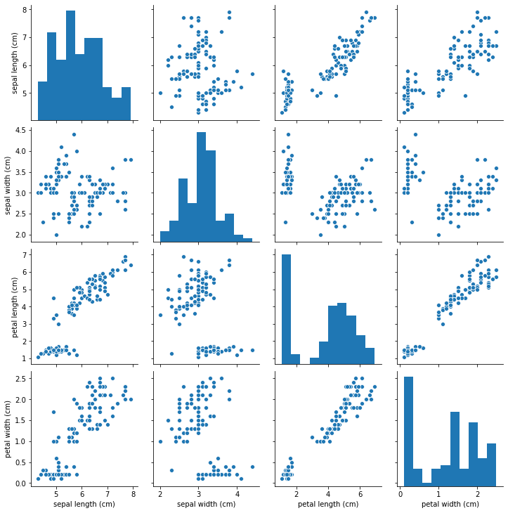

```python
sns.pairplot(iris_df.iloc[ : ,0:4])   # 1~4열 선택
```

[output not shown]

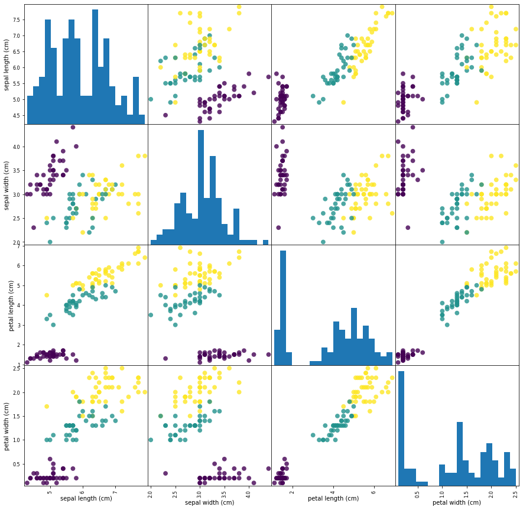

```python
pd.plotting.scatter_matrix(iris_df, c=y_train,     # 색
                          figsize=(15,15),         # 크기
                          marker='o',              # 표시
                          hist_kwds={'bins':20},   # 막대의 개수
                          s=60,     # size
                          alpha=0.8 )  # 투명도
```

### 07 첫번째 머신러닝 모델 만들기

- k-최근접 이웃(k-nearest neighbors, k-NN) 알고리즘 :
  - 훈련 데이터에서 새로운 데이터 포인트에 가장 가까운 'k개'의 이웃을 찾는다.
  - 이웃들의 클래스 중 빈도가 가장 높은 클래스를 예측값으로 사용

### 모델 만들기

```python
from sklearn.neighbors import KNeighborsClassifier
model = KNeighborsClassifier(n_neighbors=2)
```

### 모델 학습시키기

```python
model.fit(X_train, y_train)
```

```
KNeighborsClassifier(algorithm='auto', leaf_size=30, metric='minkowski',
                     metric_params=None, n_jobs=None, n_neighbors=2, p=2,
                     weights='uniform')
```

### 하나의 데이터로 예측해 보기

```python
X_new = np.array([[5, 2.9, 1, 0.2]])
```

```python
### 예측시키기
pred = model.predict(X_new)
pred_targetname = iris['target_names'][pred]
print("예측 : ", pred)
print("예측한 타깃의 이름: ", pred_targetname)
```

```
예측 :  [0]
예측한 타깃의 이름:  ['setosa']
```

### 08 내가 만든 모델 평가하기

```python
y_pred = model.predict(X_test)
print("예측값 :\n", y_pred)
```

```
예측값 :
 [2 1 0 2 0 2 0 1 1 1 2 1 1 1 1 0 1 1 0 0 2 1 0 0 2 0 0 1 1 0 2 1 0 2 2 1 0
 2]
```

```python
print("테스트 세트의 정확도 : {:.2f}".format(np.mean(y_pred == y_test)))
```

```
테스트 세트의 정확도 : 0.97
```

### 실습해 보기

- titanic 데이터 셋을 활용하여 knn 모델을 구현해 보자

### REF

sklearn score 매개변수 : https://scikit-learn.org/stable/modules/model_evaluation.html

### History

- 내용 확인 및 업데이트 2021/02/16 v11